# İstatistiksel Analiz Uygulamaları Ara Sınav Ödevi

### 9.18 Gruplar Arası Oran Testi:

```r
prop.test(nrow(data_sample[data_sample$NumWebPurchases>3,]),300,p=0.5)
```

```
##
##  1-sample proportions test with continuity correction
##
## data:  nrow(data_sample[data_sample$NumWebPurchases > 3, ]) out of 300, null probability 0.5
## X-squared = 2.0833, df = 1, p-value = 0.1489
## alternative hypothesis: true p is not equal to 0.5
## 95 percent confidence interval:
##  0.4851125 0.6004263
## sample estimates:
##         p
## 0.5433333
```

```r
prop.test(nrow(data_sample[data_sample$NumStorePurchases>5,]),300,p=0.5)
```

```
##
##  1-sample proportions test with continuity correction
##
## data:  nrow(data_sample[data_sample$NumStorePurchases > 5, ]) out of 300, null probability 0.5
## X-squared = 0.56333, df = 1, p-value = 0.4529
## alternative hypothesis: true p is not equal to 0.5
## 95 percent confidence interval:
##  0.4191650 0.5347756
## sample estimates:
##         p
## 0.4766667
```

### 9.19 İki Grubun Ortalamalarına ilişkin Karşılaştırma Testi:

```r
kid<-factor(data_sample$Kidhome, levels  = c(0,1,2), labels = c("yok", "tek", "çift"))
pairwise.t.test(data_sample$Income, kid)
```

```
##
##  Pairwise comparisons using t tests with pooled SD
##
## data:  data_sample$Income and kid
##
##      yok     tek
## tek  < 2e-16 -
## çift 0.00021 0.35375
##
## P value adjustment method: holm
```

### 9.20 Dağılımlara ilişkin Kolmogrov Smirnov Testi:

Test etmek üzere hipotezlerimizi kurduk:  
H0: Dağılımlar arasında fark yoktur.  
Hs: Dağılımlar arasında fark vardır.  
Hipotezlerimizi kurduktan sonra Normal dağılıp dağılmadığına **`shapiro.test()`** fonksiyonu ile test ettik.  
Normal dağılmayan verilerimize devamında **`ks.test()`** fonksiyonu ile Kolmogrov-Smirnov testi uyguladık.

```r
shapiro.test(data_sample$MntFruits) #normal dağılmıyor
```

```
##
##  Shapiro-Wilk normality test
##
## data:  data_sample$MntFruits
## W = 0.69365, p-value < 2.2e-16
```

```r
shapiro.test(data_sample$MntFishProducts) #normal dağılmıyor
```

```
##
##  Shapiro-Wilk normality test
##
## data:  data_sample$MntFishProducts
## W = 0.71122, p-value < 2.2e-16
```

```r
ks.test(data_sample$MntFishProducts,data_sample$MntFruits)
```

```
##
##  Two-sample Kolmogorov-Smirnov test
##
## data:  data_sample$MntFishProducts and data_sample$MntFruits
## D = 0.11667, p-value = 0.0337
## alternative hypothesis: two-sided
```

```r
#p<0.05 için H0 reddedilir. dağılımlar farklıdır.
```

Sonuç olarak ise:  
“%95 güven düzeyiyle dağılımlar arasında fark olduğu söylenebilir.” yorumu yapılabilir.

### 10.4 ggplot’a Tema Ekleme:

Veri görselleştirebilmek için **`library(ggplot2)`** kütüphanesini kullandık.  
Değişkenleri daha temiz işleyebilmek için **`attach()`** fonksiyonunu kullandık.  
Dağılım grafiğini çizdiğimiz verilerin isimlerini ise **`labs()`** fonksiyonu ile değiştirdik.  
Son olarak ise tema ekleme hususunda **`theme_bw()`** temasını kullandık.

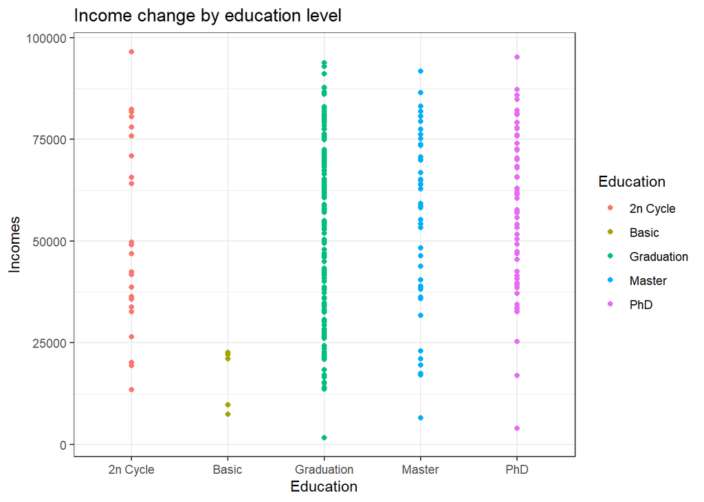

```r
library(ggplot2)
attach(data_sample)
ggplot(data_sample, aes(Education, Income, color=Education)) +
  geom_point() +
  theme_bw() +
  labs(title = "Income change by education level ",
       x = "Education",
       y = "Incomes")
```

```r
detach(data_sample)
```

##### Grafik yorumu:

“Basic eğitim almış kişiler daha düşük maaşlı işlerde çalışırken, Graduation, Master ve PhD eğitimi almış kişiler daha yüksek maaşlı işlerde çalışmış” yorumunu yaptık.  
2ndCycle kısmında ise aralık olarak Graduation kısmına benzese de Graduation kadar yoğunluk elde edememiş, standart sapması diğerlerine göre daha yüksek bir seviyede kalmış.

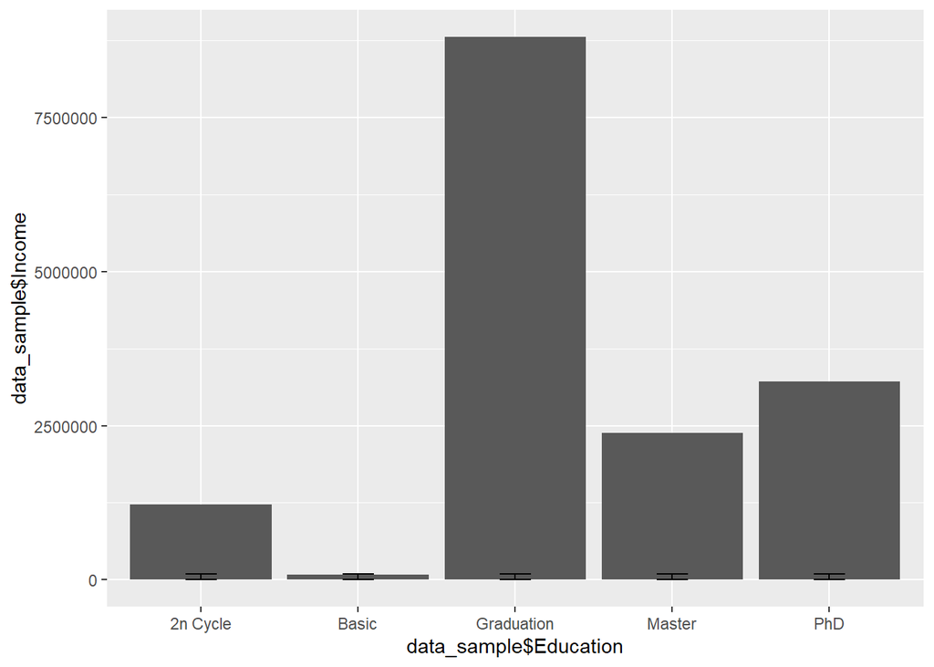

```r
ggplot(data_sample, aes(data_sample$Education,data_sample$Income)) +
  geom_bar(stat="identity") +
  geom_errorbar(aes(ymin=min(data_sample$Income,na.rm=T), ymax=max(data_sample$Income,na.rm=T)), width=.2)
```

### 10.12 Bar Grafiğini Renklendirme:

Bar grafiğini renklendirdik.

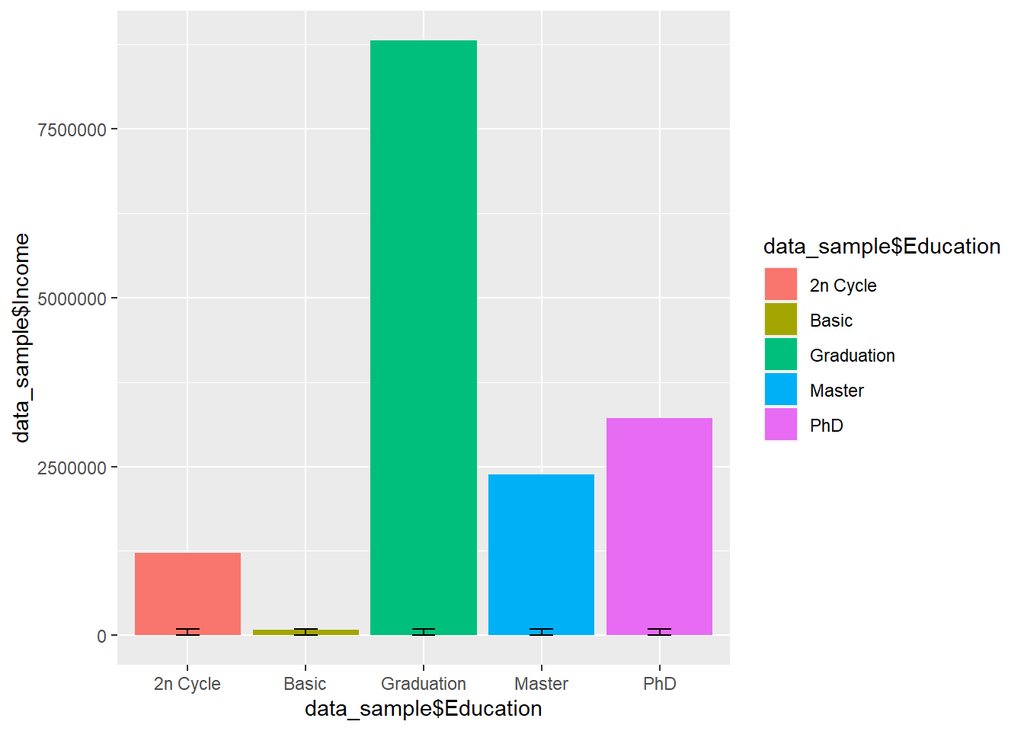

```r
ggplot(data_sample, aes(data_sample$Education, data_sample$Income, fill = data_sample$Education)) +
  geom_bar(stat="identity") +
  geom_errorbar(aes(ymin=min(data_sample$Income,na.rm=T), ymax=max(data_sample$Income,na.rm=T)), width=.2)
```

### 10.13 Çizgi Grafiği Çizme:

**`ggplot()`** fonksiyonunun sonuna **`geom_line()`** fonksiyonu ile çizgi grafiğini çizdirdik.

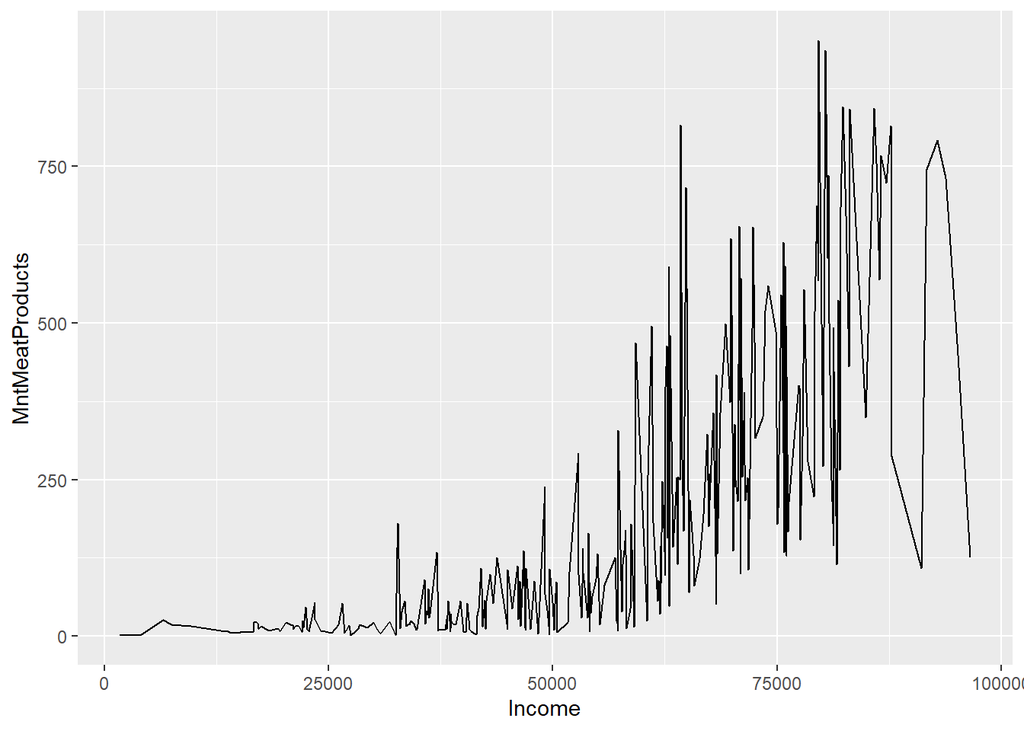

```r
attach(data_sample)
ggplot(data_sample, aes(Income, MntMeatProducts)) +
  geom_line()
```

```r
detach(data_sample)
```

##### Grafik yorumu:

Gelir düzeyi arttıkça müşterilerin et alımı artış eğilimi göstermektedir.

### 10.15 İkili Çizgi Grafiği Çizme:

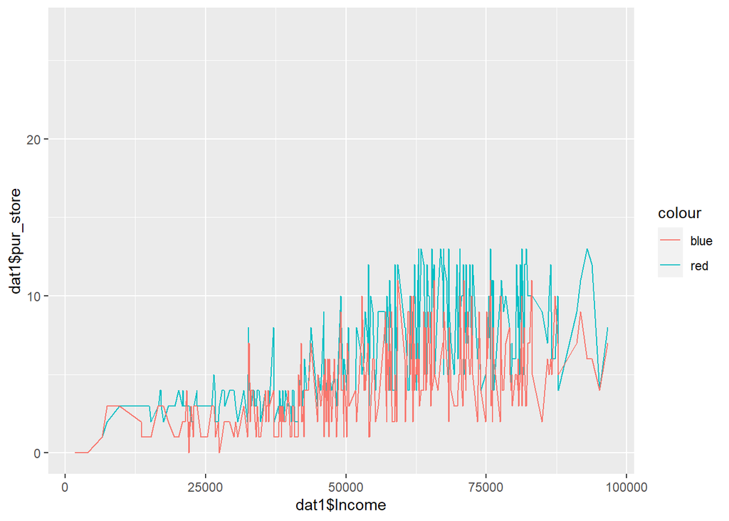

```r
library(dplyr)
dat1<-data_sample %>%
  summarize(Income=Income, pur_store=NumStorePurchases)
dat2 <- data_sample %>%
  summarize(Income=Income, pur_web=NumWebPurchases)
ggplot() +
  geom_line(data = dat1, aes(dat1$Income, dat1$pur_store, color="red")) +
  geom_line(data = dat2, aes(dat1$Income, dat2$pur_web, color="blue"))
```

### 10.16 Dikey ve Yatay Çizgiler Ekleme:

Gelir düzeyindeki ortalamasını gösteren olarak kırmızı kesikli çizgi, et alımının ortalamasını ise mavi yatay düz çizgi olarak belirledik.

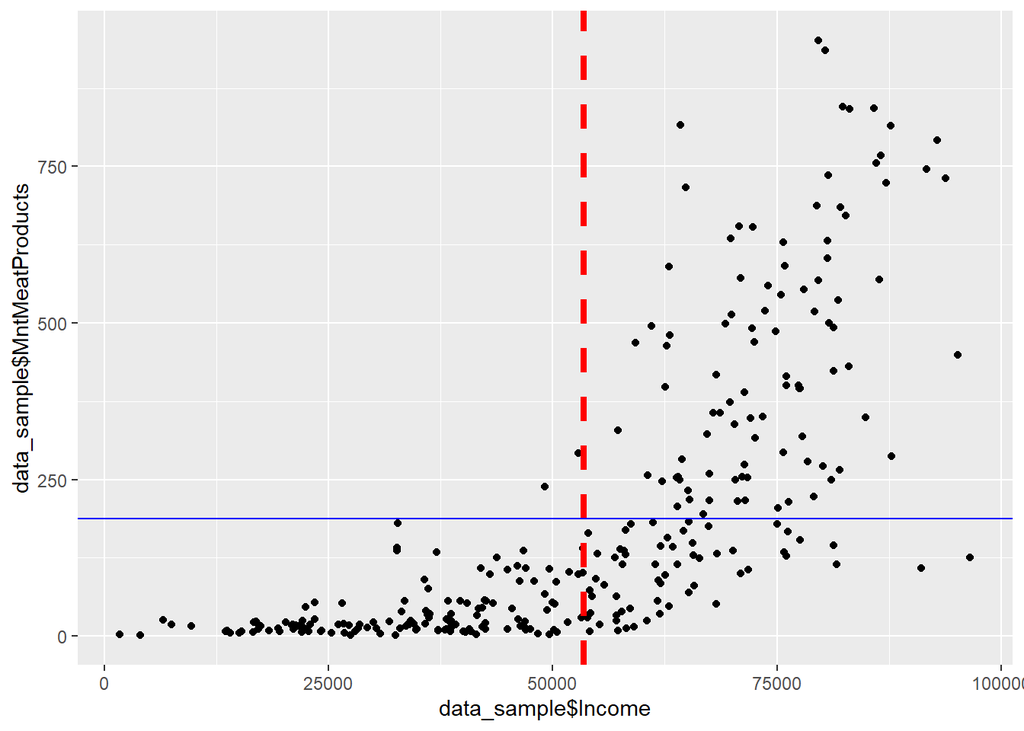

```r
ggplot(data_sample, aes(data_sample$Income, data_sample$MntMeatProducts)) + geom_point() +
geom_vline(
  xintercept = mean(data_sample$Income , na.rm=T),
  color = "red",
  linetype = "dashed",
  size = 1.5
) +
  geom_hline(yintercept = mean(data_sample$MntMeatProducts, na.rm=T), color = "blue")
```

### 10.17 Boxplot (Kutu) Grafiği:

Diğer grafiklerden farklı olara **`geom_boxplot()`** fonksiyonu ile kutu grafiğimizi çizdirdik.

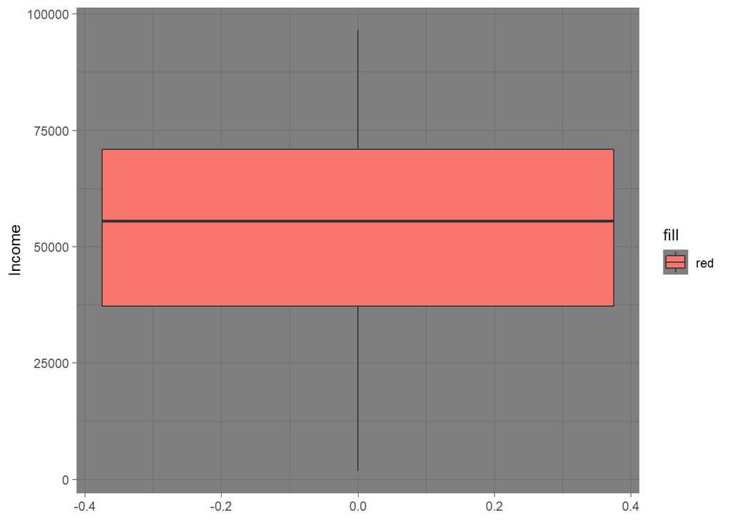

```r
ggplot(data_sample) +
aes(y = Income, fill = "red") +
  geom_boxplot() + theme_dark()
```

### 10.18 Herbir Grup için Boxplot (Kutu) Grafiği:

Faktör olarak **`Marital_Status`** değişkeni ile müşterilerin medeni durumu kabul edilmiştir. Grafiği çizdirilecek olan ise **`Income`** değişkeni ile gelir düzeyi alınmıştır.

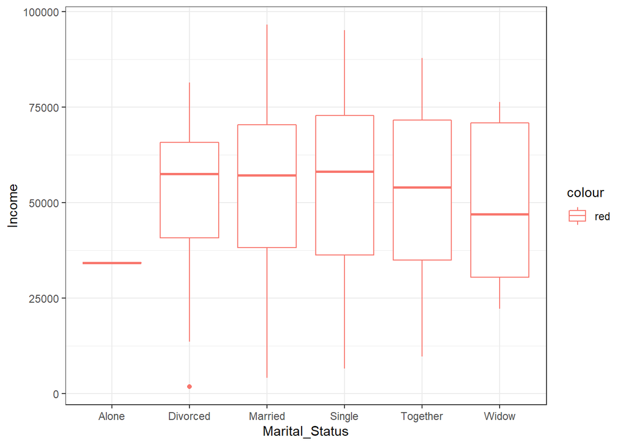

```r
ggplot(data_sample) +
  aes(x=Marital_Status, y = Income, color="red") +
  geom_boxplot() + theme_bw()
```

### 10.20 Histogram Grafiği Çözdürme:

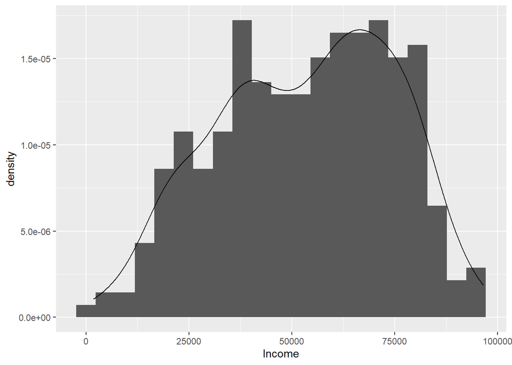

```r
attach(data_sample)

ggplot() +
  aes(x = Income) +
  geom_histogram(aes(y =  ..density..), bins = 21) +
  geom_density()
```

```r
detach(data_sample)
```

##### Grafik Yorumu:

Grafiğe baktığımızda söyleyebilirz ki, en fazla yoğunluğa sahip olan gelir aralığı [50.000 - 75.000] arasında dağılmaktadır.